# Using Tidymodels to Predict Churn

Mike Kaminski

2023-11-20

# 1 Background

This data is from an old Kaggle competition - https://www.kaggle.com/datasets/blastchar/telco-customer-churn

The data set includes information about:

- Customers who left within the last month – the column is called Churn
- Services that each customer has signed up for – phone, multiple lines, internet, online security, online backup, device protection, tech support, and streaming TV and movies
- Customer account information – how long they’ve been a customer, contract, payment method, paperless billing, monthly charges, and total charges
- Demographic info about customers – gender, age range, and if they have partners and dependents

I’ve recently started using tidymodels instead of caret, so I wanted to run through an example.

# 2 Libraries, Data, and Quick Review

```r
library(tidymodels)
#broom, dials, dplyr, ggplot2, infer, parsnip, purrr, recipes, rsample, tibble, tune, workflows, yardstick

tidymodels_prefer()
library(knitr)
```

Initial Data Review

- Many of the columns have character values, but they should really be factors
- customerID isn’t needed for modeling purposes, but it’s worth including in the data frame for now in case research needs to done after modeling is complete
- SeniorCitizens is numeric, but it should be a character/factor
- Total Charges appears to be the product of MonthlyCharges and Tenure

```r
summary(data)
```

```
##   customerID           gender          SeniorCitizen      Partner
##  Length:7043        Length:7043        Min.   :0.0000   Length:7043
##  Class :character   Class :character   1st Qu.:0.0000   Class :character
##  Mode  :character   Mode  :character   Median :0.0000   Mode  :character
##                                        Mean   :0.1621
##                                        3rd Qu.:0.0000
##                                        Max.   :1.0000
##
##   Dependents            tenure      PhoneService       MultipleLines
##  Length:7043        Min.   : 0.00   Length:7043        Length:7043
##  Class :character   1st Qu.: 9.00   Class :character   Class :character
##  Mode  :character   Median :29.00   Mode  :character   Mode  :character
##                     Mean   :32.37
##                     3rd Qu.:55.00
##                     Max.   :72.00
##
##  InternetService    OnlineSecurity     OnlineBackup       DeviceProtection
##  Length:7043        Length:7043        Length:7043        Length:7043
##  Class :character   Class :character   Class :character   Class :character
##  Mode  :character   Mode  :character   Mode  :character   Mode  :character
##
##
##
##
##  TechSupport        StreamingTV        StreamingMovies      Contract
##  Length:7043        Length:7043        Length:7043        Length:7043
##  Class :character   Class :character   Class :character   Class :character
##  Mode  :character   Mode  :character   Mode  :character   Mode  :character
##
##
##
##
##  PaperlessBilling   PaymentMethod      MonthlyCharges    TotalCharges
##  Length:7043        Length:7043        Min.   : 18.25   Min.   :  18.8
##  Class :character   Class :character   1st Qu.: 35.50   1st Qu.: 401.4
##  Mode  :character   Mode  :character   Median : 70.35   Median :1397.5
##                                        Mean   : 64.76   Mean   :2283.3
##                                        3rd Qu.: 89.85   3rd Qu.:3794.7
##                                        Max.   :118.75   Max.   :8684.8
##                                                         NA's   :11
##     Churn
##  Length:7043
##  Class :character
##  Mode  :character
##
##
##
##
```

Update the data

```r
df_churn <- data |>

  # update SeniorCitizen to a character value
  mutate(SeniorCitizen = ifelse(SeniorCitizen == 0, "No","Yes")) |>

  # replace NAs in TotalCharges with 0.  When filtering the NAs, all these customers had a tenure of 0, meaning they haven't paid anything...yet
  mutate(TotalCharges = ifelse(is.na(TotalCharges),0,TotalCharges)) |>

  # I also want to create variables for Phone Only, Internet Only, or Both
  mutate(Package = ifelse(PhoneService %in% 'Yes' & InternetService %in% 'No', 'PhoneOnly',
                          ifelse(InternetService %in% c('DSL','Fiber Optic') & PhoneService %in% 'No', 'InternetOnly','Both'))) |>
  # Put Churn at the front
  select(Churn,everything())
```

# 3 EDA and Correlation

This code utilizes a recipe to create a data frame for each of the factor variables. Rather than creating dummy variables, setting one_hot = TRUE creates an indicator column for each option. This is better because I want to see how each of the factors compares to the Churn variable.

If I had used one_hot = FALSE, than the column for contract type would NOT show me month to month, one year, and two year, it would just show 2 of the 3 options.

```r
corr_obj <- df_churn |> select(-customerID) |>
  recipe(~ .) |>
  step_dummy(all_nominal(), one_hot = TRUE )

corr_prep <- prep(corr_obj)

corr_df <- bake(corr_prep, new_data = df_churn)
```

Reviews the correlation between Churn and all the variables

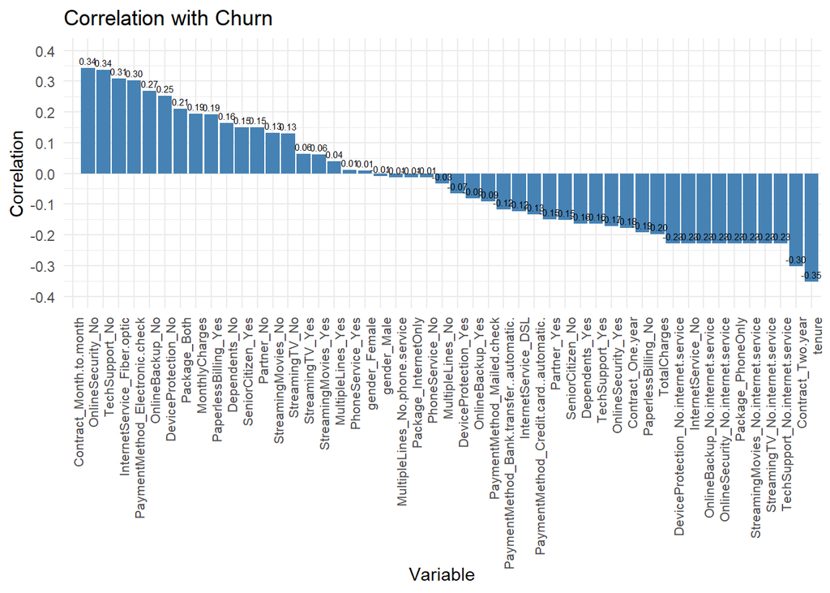

```r
# Creates a matrix by expanding factor variables to a set of 'dummy variables'
churn_corr <- as.data.frame(model.matrix(~., data = corr_df)) |> select(-1)

m <- cor(churn_corr)

m_churn <- m['Churn_Yes', ]

m_churn_df <- data.frame(variable = names(m_churn), correlation = m_churn)

m_churn_df |>
  filter(variable != c('Churn_Yes','Churn_No')) |>
  ggplot(aes(x = reorder(variable,-correlation), y = correlation)) +
  geom_bar(stat = "identity", position = "identity", fill = 'steelblue') +
  geom_text(aes(label = sprintf("%.2f", correlation)),size = 2, vjust = -0.5,
            position = position_dodge(width = 0.8)) +

  labs(title = 'Correlation with Churn', y = 'Correlation',x = 'Variable') +
  theme_minimal() +
  theme(axis.text.x = element_text(angle = 90, hjust = 1, size = 8)) +
  scale_y_continuous(limits = c(-0.4, 0.4), breaks = seq(-0.4, 0.4, by = 0.1))
```

From this bar plot, we can see that month to month contracts, no online security, no tech support, and Fiber Optic internet have the strongest positive correlations and tenure and 2 year contract have the strongest negative correlations - meaning that they are positively correlated with not churning.

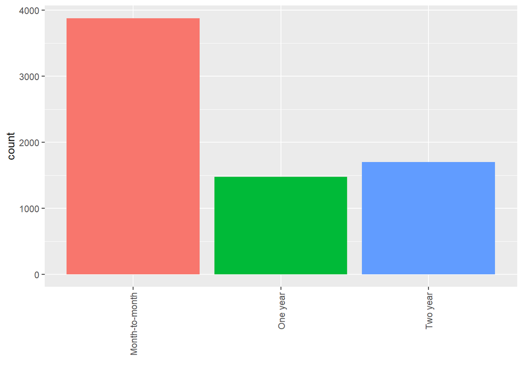

```r
# month to month is the most common contract
df_churn %>%
    ggplot(aes(x = Contract, fill = Contract)) +
    geom_bar() +
    theme(legend.position="none") +
    labs(x ="") +
    theme(axis.text.x = element_text(angle = 90, vjust = 0.5, hjust = 1))
```

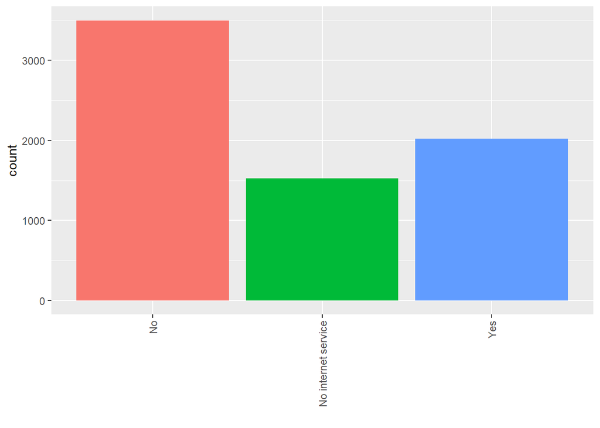

```r
# having no online security is the most common option
df_churn %>%
    ggplot(aes(x = OnlineSecurity, fill = OnlineSecurity)) +
    geom_bar() +
    theme(legend.position="none") +
    labs(x ="") +
    theme(axis.text.x = element_text(angle = 90, vjust = 0.5, hjust = 1))
```

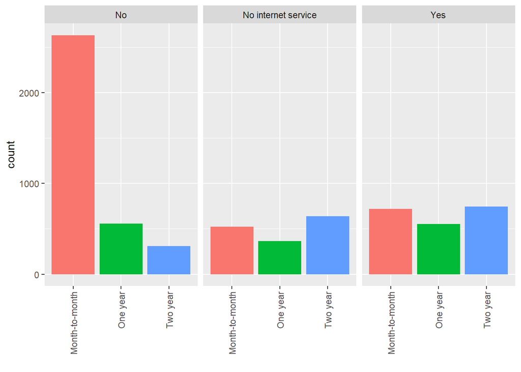

```r
# month to month and no online security is the most common
df_churn %>%
    ggplot(aes(x = Contract, fill = Contract)) +
    geom_bar() +
    facet_wrap(vars(OnlineSecurity)) +
    theme(legend.position="none") +
    labs(x ="") +
    theme(axis.text.x = element_text(angle = 90, vjust = 0.5, hjust = 1))
```

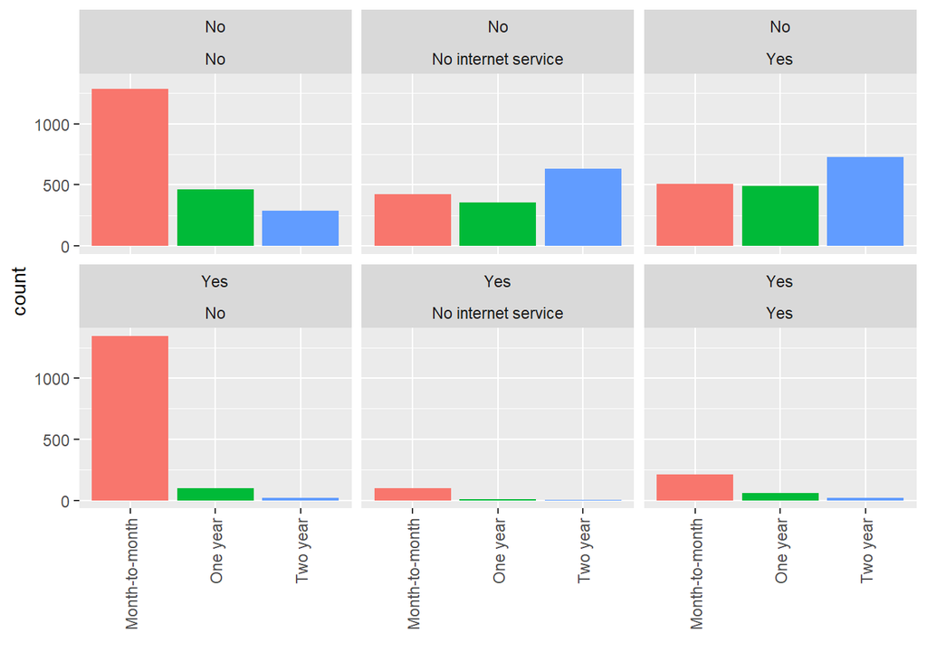

```r
# much of the churn appears to come from month to month contracts with No Online Security
df_churn %>%
  ggplot(aes(x = Contract, fill = Contract)) +
  geom_bar() +
  facet_wrap(vars(Churn, OnlineSecurity)) +
  theme(legend.position="none") +
  labs(x ="") +
  theme(axis.text.x = element_text(angle = 90, vjust = 0.5, hjust = 1))
```

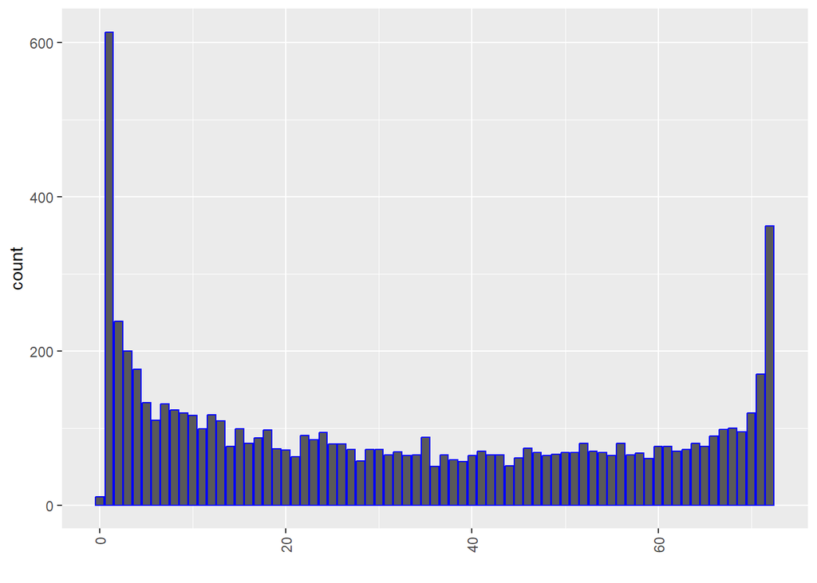

```r
# There are a lot of shorter tenures
df_churn %>%
    ggplot(aes(x = tenure)) +
    geom_bar(color = "blue") +
    theme(legend.position="none") +
    labs(x ="") +
    theme(axis.text.x = element_text(angle = 90, vjust = 0.5, hjust = 1))
```

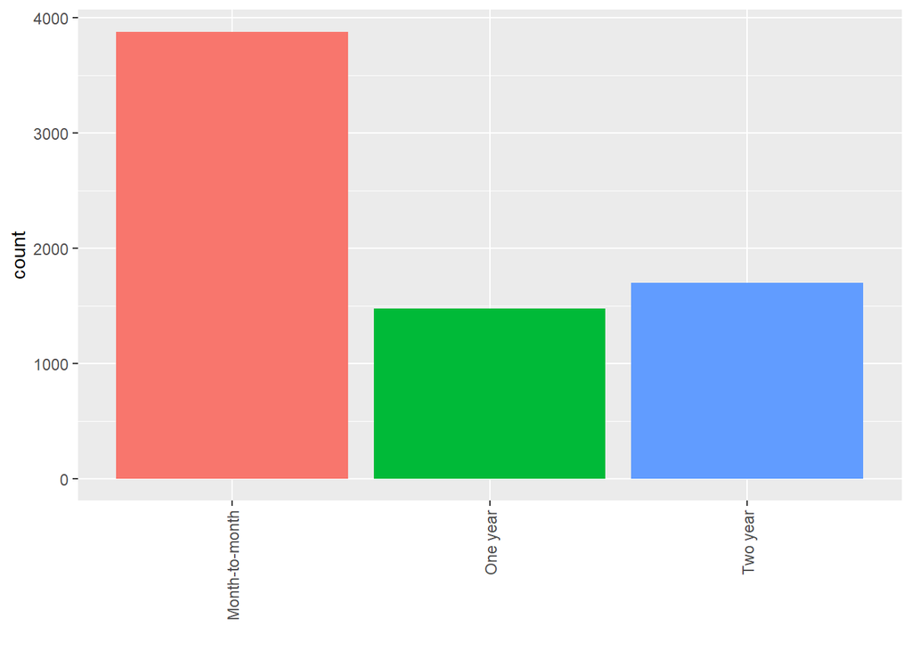

```r
# Month-to-month is the most common contract
df_churn %>%
    ggplot(aes(x = Contract, fill = Contract)) +
    geom_bar() +
    theme(legend.position="none") +
    labs(x ="") +
    theme(axis.text.x = element_text(angle = 90, vjust = 0.5, hjust = 1))
```

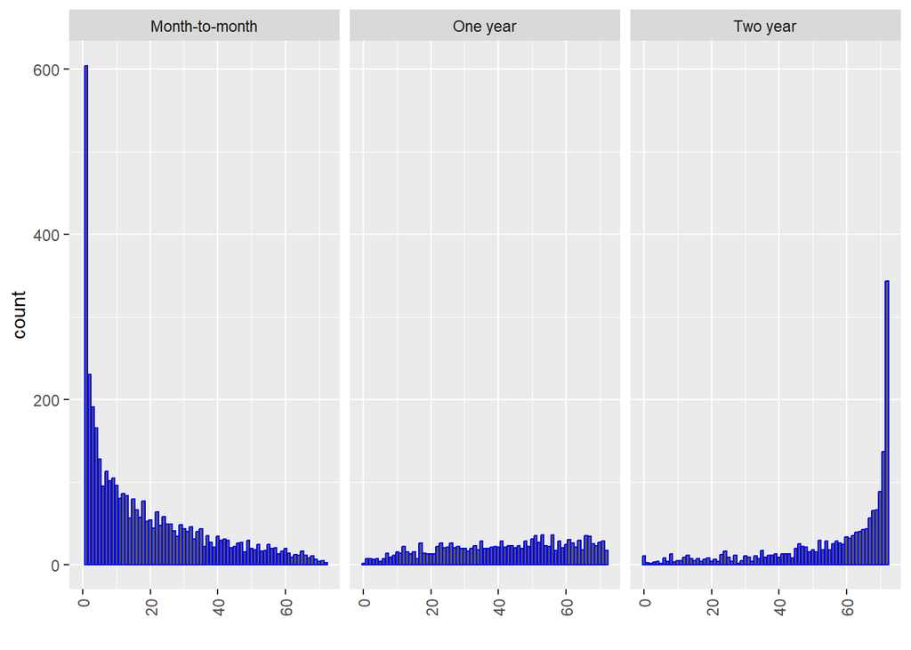

```r
# Month-to-month have shorter tenures, two year contracts have longer tenures
df_churn %>%
    ggplot(aes(x = tenure)) +
    geom_bar(color = "blue") +
    facet_wrap(vars(Contract)) +
    theme(legend.position="none") +
    labs(x ="") +
    theme(axis.text.x = element_text(angle = 90, vjust = 0.5, hjust = 1))
```

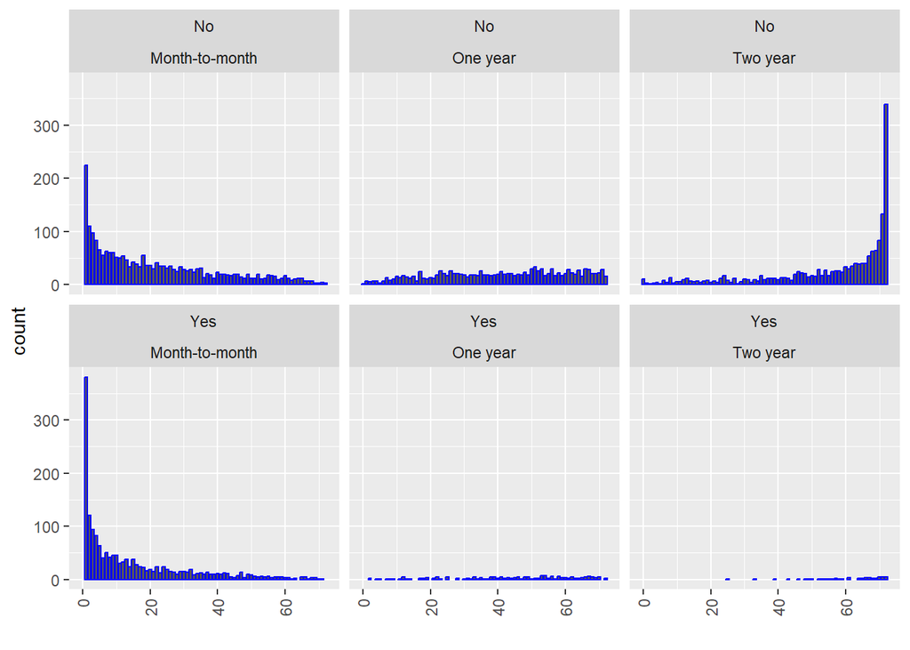

```r
# much of the churn appears to come from month to month clients with a shorter tenure
df_churn %>%
    ggplot(aes(x = tenure)) +
    geom_bar(color = "blue") +
    facet_wrap(vars(Churn, Contract)) +
    theme(legend.position="none") +
    labs(x ="") +
    theme(axis.text.x = element_text(angle = 90, vjust = 0.5, hjust = 1))
```

# 4 Model Setup

I’ll split the data on the Churn variable and use 10 fold cross-validation for the training and tuning processes

```r
# create a model data frame and change values to  factors
model_df <- df_churn |> mutate_if(is.character, as.factor) |> mutate(customerID = as.character(customerID))
```

## 4.1 Splitting and Cross-Validation

```r
set.seed(21425)
churn_split <- initial_split(model_df, strata = Churn)
churn_train <- training(churn_split)
churn_test <- testing(churn_split)

set.seed(1502)
churn_folds <-
   vfold_cv(churn_train, strata = Churn)
```

## 4.2 Recipes

The models that use distance functions will need to be normalized, so I’ll create two different recipes

```r
model_recipe_no_norm <-
  recipe(Churn ~ ., churn_train) |>

  # keeps the custID in case we have to explore a specific customer
  update_role(customerID, new_role = "ID") |> # keeps the custID in case we have to explore a specific customer

  #Creates dummy variables
  step_dummy(all_nominal_predictors()) |>

  #removes variables with zero variance, if any
  step_zv(all_predictors())

model_recipe_norm <- model_recipe_no_norm |>

  # Normalizes the data
  step_normalize(all_numeric_predictors())
```

## 4.3 Building Model Specifications

I’ve created model specifications below. These will be used in a workflow for each model. For all except for glmnet - I need to specify the mode - classification.

```r
glm_spec <-
  logistic_reg(penalty = tune(),
               mixture = tune() # range from 0 to 1, with 1 being a pure Lasso model
               ) |>
  set_engine("glmnet")

rf_spec <-
   rand_forest(mtry = tune(),
               min_n = tune(),
               trees = 1000 # trees of 1000 should be sufficient
               ) |>
   set_engine("ranger") |>
   set_mode("classification")

xgb_spec <-
   boost_tree(trees = 1000, # trees of 1000 should be sufficient
              tree_depth = tune(),
              min_n = tune(),
              learn_rate = tune(),
              loss_reduction = tune(),
              mtry = tune(),
              sample_size = tune()
              ) |>
   set_engine("xgboost") |>
   set_mode("classification")

svm_spec <-
  svm_rbf(cost = tune(), rbf_sigma = tune()) |>
  set_engine("kernlab") |>
  set_mode("classification")

knn_spec <-
   nearest_neighbor(neighbors = tune(),
                    dist_power = tune(),
                    weight_func = tune()) |>
   set_engine("kknn") |>
   set_mode("classification")
```

# 5 Modeling

## 5.1 Penalized Logistic Regression

Create a workflow

```r
glmnet_wf <-
  workflow() |>
  add_model(glm_spec) |>
  add_recipe(model_recipe_norm)
```

Create a grid

```r
glmnet_grid <- grid_regular(penalty(),
                          mixture(),
                          levels = 5)
```

Tune the hyperparameters

```r
set.seed(345)

glmnet_tune <-
  glmnet_wf %>%
  tune_grid(
    resamples = churn_folds,
    control = control_grid(save_pred = TRUE),
    grid = glmnet_grid
    )

saveRDS(glmnet_tune, file = "Saved_Model_Results/glmnet_initial_tune.rds")
```

Results of tuning

```r
options(scipen = 4)
glmnet_tune |>
  collect_metrics() |>
  filter(.metric == "roc_auc") |>
  arrange(-mean,penalty, mixture) |>
  head(10) |>
  kable()
```

| penalty | mixture | .metric | .estimator | mean | n | std_err | .config |
| --- | --- | --- | --- | --- | --- | --- | --- |
| 0.00000 | 1.00 | roc_auc | binary | 0.8411495 | 10 | 0.0051941 | Preprocessor1_Model21 |
| 0.00000 | 1.00 | roc_auc | binary | 0.8411495 | 10 | 0.0051941 | Preprocessor1_Model22 |
| 0.00001 | 1.00 | roc_auc | binary | 0.8411495 | 10 | 0.0051941 | Preprocessor1_Model23 |
| 0.00000 | 0.25 | roc_auc | binary | 0.8411255 | 10 | 0.0051760 | Preprocessor1_Model06 |
| 0.00000 | 0.25 | roc_auc | binary | 0.8411255 | 10 | 0.0051760 | Preprocessor1_Model07 |
| 0.00001 | 0.25 | roc_auc | binary | 0.8411255 | 10 | 0.0051760 | Preprocessor1_Model08 |
| 0.00000 | 0.50 | roc_auc | binary | 0.8411199 | 10 | 0.0051826 | Preprocessor1_Model11 |
| 0.00000 | 0.50 | roc_auc | binary | 0.8411199 | 10 | 0.0051826 | Preprocessor1_Model12 |
| 0.00001 | 0.50 | roc_auc | binary | 0.8411199 | 10 | 0.0051826 | Preprocessor1_Model13 |
| 0.00000 | 0.75 | roc_auc | binary | 0.8411145 | 10 | 0.0051871 | Preprocessor1_Model16 |

Plot of tuning results

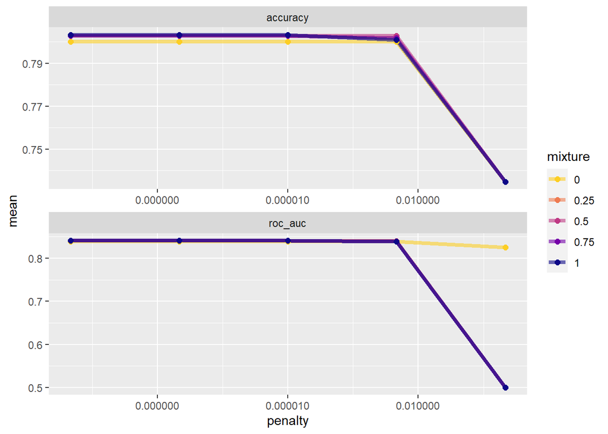

```r
glmnet_tune %>%
  collect_metrics() %>%
  mutate(mixture = factor(mixture)) %>%
  ggplot(aes(penalty, mean, color = mixture)) +
  geom_line(size = 1.5, alpha = 0.6) +
  geom_point(size = 2) +
  facet_wrap(~ .metric, scales = "free", nrow = 2) +
  scale_x_log10(labels = scales::label_number()) +
  scale_color_viridis_d(option = "plasma", begin = .9, end = 0)
```

Lower penalties seem to do well, however mixture isn’t quite as clear - they all have rocs_aucs of around 0.83 and 0.84 Smaller penalties appear to do better, so I can re-tune and define a range of values for penalty.

```r
# rebuild the grid
glmnet_grid <- grid_regular(penalty(range = c(-10,-5)), # range is -10 to 0 and on the log scale
                          mixture(),
                          levels = 5)

# Modeling
set.seed(345)

glmnet_retune <-
  glmnet_wf %>%
  tune_grid(
    resamples = churn_folds,
    control = control_grid(save_pred = TRUE),
    grid = glmnet_grid
    )

saveRDS(glmnet_retune, file = "Saved_Model_Results/glmnet_retune.rds")

options(scipen = 9)
# Collect metrics
glmnet_retune |>
  collect_metrics() |>
  filter(.metric == "roc_auc") |>
  arrange(-mean,penalty, mixture) |>
  head(10) |>
  kable()
```

| penalty | mixture | .metric | .estimator | mean | n | std_err | .config |
| --- | --- | --- | --- | --- | --- | --- | --- |
| 0.0000000 | 1.00 | roc_auc | binary | 0.8411495 | 10 | 0.0051941 | Preprocessor1_Model21 |
| 0.0000000 | 1.00 | roc_auc | binary | 0.8411495 | 10 | 0.0051941 | Preprocessor1_Model22 |
| 0.0000000 | 1.00 | roc_auc | binary | 0.8411495 | 10 | 0.0051941 | Preprocessor1_Model23 |
| 0.0000006 | 1.00 | roc_auc | binary | 0.8411495 | 10 | 0.0051941 | Preprocessor1_Model24 |
| 0.0000100 | 1.00 | roc_auc | binary | 0.8411495 | 10 | 0.0051941 | Preprocessor1_Model25 |
| 0.0000000 | 0.25 | roc_auc | binary | 0.8411255 | 10 | 0.0051760 | Preprocessor1_Model06 |
| 0.0000000 | 0.25 | roc_auc | binary | 0.8411255 | 10 | 0.0051760 | Preprocessor1_Model07 |
| 0.0000000 | 0.25 | roc_auc | binary | 0.8411255 | 10 | 0.0051760 | Preprocessor1_Model08 |
| 0.0000006 | 0.25 | roc_auc | binary | 0.8411255 | 10 | 0.0051760 | Preprocessor1_Model09 |
| 0.0000100 | 0.25 | roc_auc | binary | 0.8411255 | 10 | 0.0051760 | Preprocessor1_Model10 |

Not much of a change using smaller penalties, but a mixture of 1 (pure lasso) appears to be the best.

Select the best parameters

```r
options(scipen = 9)
best_glmnet <- glmnet_retune %>%
  select_best("roc_auc")
best_glmnet
```

```
## # A tibble: 1 × 3
##        penalty mixture .config
##          <dbl>   <dbl> <chr>
## 1 0.0000000001       1 Preprocessor1_Model21
```

Finalized glmnet model

Create a workflow using the best penalty and mixture - a low penalty and a pure lasso regularization.

```r
glmnet_wf <-
  glmnet_wf %>%
  finalize_workflow(best_glmnet)
```

Final Model

- last_fit() emulates the process where, after determining the best model - aka from final_wf, the final fit on the entire training set is needed and is then evaluated on the test set.

```r
glmnet_final <-
  glmnet_wf %>%
  last_fit(churn_split)

saveRDS(glmnet_final, file = "Saved_Model_Results/glmnet_final.rds")

#Metrics
glmnet_final %>%
  collect_metrics()
```

```
## # A tibble: 2 × 4
##   .metric  .estimator .estimate .config
##   <chr>    <chr>          <dbl> <chr>
## 1 accuracy binary         0.807 Preprocessor1_Model1
## 2 roc_auc  binary         0.858 Preprocessor1_Model1
```

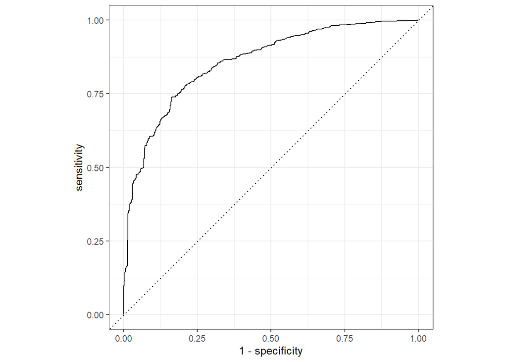

```r
#roc curve
glmnet_final %>%
  collect_predictions() %>%
  roc_curve(Churn, .pred_No) %>%
  autoplot()
```

## 5.2 Random Forest

Create a workflow

```r
rf_wf <-
  workflow() |>
  add_model(rf_spec) |>
  add_recipe(model_recipe_no_norm)
```

Tuning the Hyperparameters

- This will be trained a bit differently than glmnet RF models tend to perform well without tuning, but it doesn’t hurt to explore a bit. I’ll be using tune_grid initially instead of grid_regular for this tuning process

```r
doParallel::registerDoParallel()

set.seed(12542)
rf_tune <- tune_grid(
  rf_wf,
  resamples = churn_folds,
  grid = 30
)
```

```
## i Creating pre-processing data to finalize unknown parameter: mtry
```

```r
saveRDS(rf_tune, file = "Saved_Model_Results/rf_initial_tune.rds")
```

Metrics

```r
rf_tune |>
  collect_metrics() |>
  filter(.metric == "roc_auc") |>
  arrange(-mean) |>
  head(10) |>
  kable()
```

| mtry | min_n | .metric | .estimator | mean | n | std_err | .config |
| --- | --- | --- | --- | --- | --- | --- | --- |
| 5 | 28 | roc_auc | binary | 0.8419630 | 10 | 0.0049751 | Preprocessor1_Model26 |
| 3 | 17 | roc_auc | binary | 0.8410658 | 10 | 0.0047453 | Preprocessor1_Model05 |
| 7 | 30 | roc_auc | binary | 0.8406773 | 10 | 0.0050237 | Preprocessor1_Model02 |
| 9 | 32 | roc_auc | binary | 0.8395159 | 10 | 0.0051026 | Preprocessor1_Model18 |
| 8 | 23 | roc_auc | binary | 0.8387182 | 10 | 0.0049896 | Preprocessor1_Model27 |
| 12 | 33 | roc_auc | binary | 0.8379905 | 10 | 0.0051707 | Preprocessor1_Model12 |
| 10 | 22 | roc_auc | binary | 0.8369434 | 10 | 0.0050522 | Preprocessor1_Model28 |
| 14 | 35 | roc_auc | binary | 0.8368982 | 10 | 0.0052511 | Preprocessor1_Model14 |
| 6 | 7 | roc_auc | binary | 0.8363543 | 10 | 0.0047926 | Preprocessor1_Model22 |
| 2 | 29 | roc_auc | binary | 0.8354133 | 10 | 0.0045600 | Preprocessor1_Model21 |

Plots

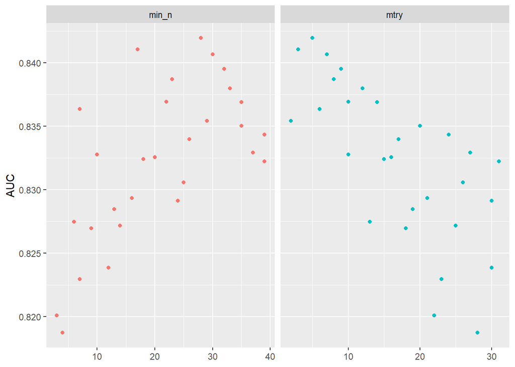

```r
rf_tune %>%
  collect_metrics() %>%
  filter(.metric == "roc_auc") %>%
  select(mean, min_n, mtry) %>%
  pivot_longer(min_n:mtry,
    values_to = "value",
    names_to = "parameter"
  ) %>%
  ggplot(aes(value, mean, color = parameter)) +
  geom_point(show.legend = FALSE) +
  facet_wrap(~parameter, scales = "free_x") +
  labs(x = NULL, y = "AUC")
```

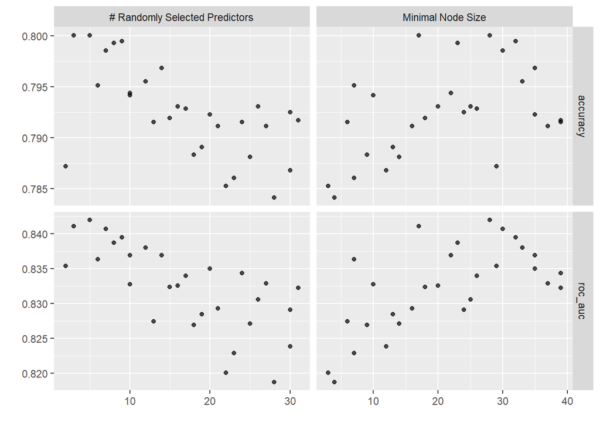

```r
autoplot(rf_tune)
```

Generally it looks like a min_n between 23 and 33 and an mtry between 3 and 9

Now that we have a range of values to use, grid_regular can be utilized.

```r
rf_grid <- grid_regular(
  mtry(range = c(3, 9)),
  min_n(range = c(23, 33)),
  levels = 7
)
```

Re-tuning and Plotting

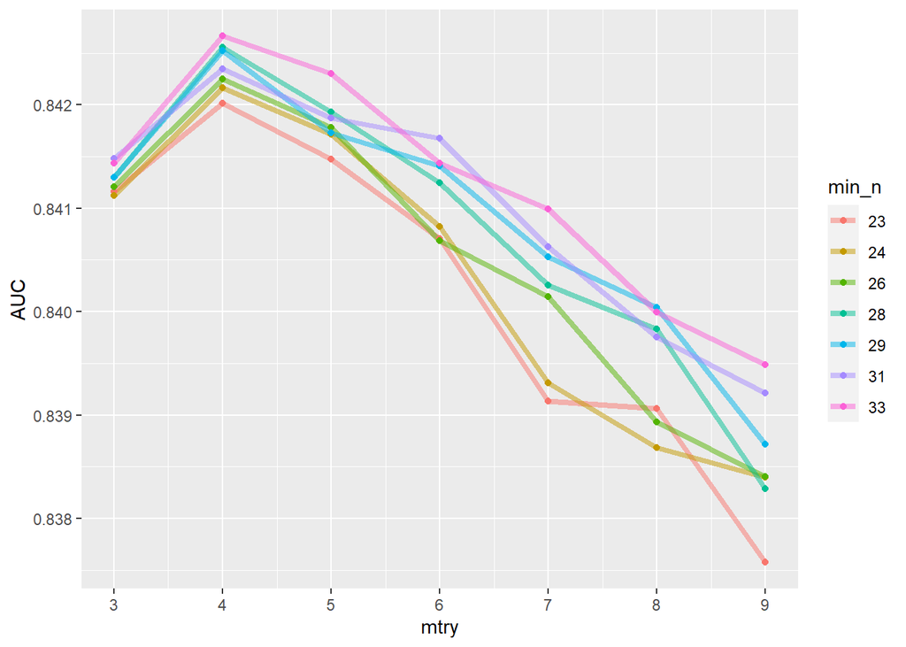

```r
set.seed(456)
rf_retune <- tune_grid(
  rf_wf,
  resamples = churn_folds,
  grid = rf_grid
)

saveRDS(rf_retune, file = "Saved_Model_Results/rf_retune.rds")

rf_retune %>%
  collect_metrics() %>%
  filter(.metric == "roc_auc") %>%
  mutate(min_n = factor(min_n)) %>%
  ggplot(aes(mtry, mean, color = min_n)) +
  geom_line(alpha = 0.5, size = 1.5) +
  geom_point() +
  labs(y = "AUC") +
  scale_x_continuous(breaks = seq(0, 12, by = 1))
```

An mtry of 4 and a min_n of 33 perform the best

Best Model

```r
best_rf <- rf_retune %>% select_best("roc_auc")
best_rf
```

```
## # A tibble: 1 × 3
##    mtry min_n .config
##   <int> <int> <chr>
## 1     4    33 Preprocessor1_Model44
```

Finalized Model

```r
# final_rf <-
#   workflow() %>%
#   add_recipe(model_recipe_no_norm) %>%
#   add_model(final_rf)

rf_wf <-
  rf_wf |>
  finalize_workflow(best_rf)

rf_final <-
  rf_wf %>%
  last_fit(churn_split)

saveRDS(rf_final, file = "Saved_Model_Results/rf_final.rds")

rf_final %>%
  collect_metrics()
```

```
## # A tibble: 2 × 4
##   .metric  .estimator .estimate .config
##   <chr>    <chr>          <dbl> <chr>
## 1 accuracy binary         0.804 Preprocessor1_Model1
## 2 roc_auc  binary         0.854 Preprocessor1_Model1
```

```r
conf_mat_resampled(rf_final)
```

```
## # A tibble: 4 × 3
##   Prediction Truth  Freq
##   <fct>      <fct> <dbl>
## 1 No         No     1187
## 2 No         Yes     239
## 3 Yes        No      107
## 4 Yes        Yes     229
```

Variable Importance Plot

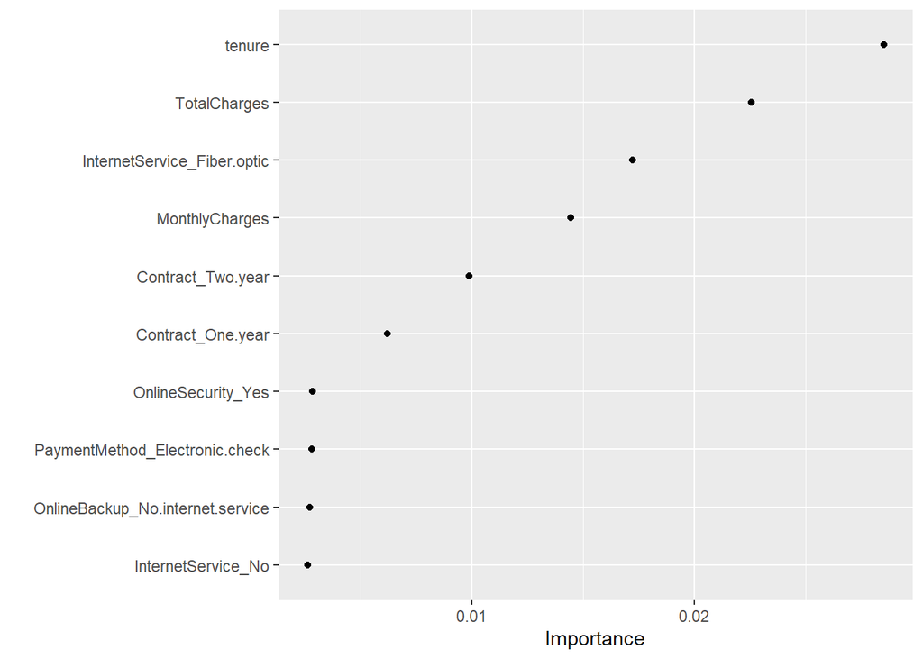

```r
library(vip)

rf_vip <-
  rf_spec %>%
  finalize_model(select_best(rf_retune)) %>%
  set_engine("ranger", importance = "permutation")  # need to add a way to compute importance, so the engine needs to be adjusted

workflow() |>
  add_recipe(model_recipe_no_norm) |>
  add_model(rf_vip) |>
  fit(churn_train) %>%
  pull_workflow_fit() |>
  vip(geom = "point")
```

Tenure and TotalCharges are important, but they’re definitely correlated - TotalCharges is the product of tenure and MonthlyCharges. Fiber Optic is also important as well as Monthly Charges - which by itself is a good indicator

## 5.3 XGBoost

Arguments for the xgboost

- mtry - same as rf; the number of predictors that are randomly sampled at each split
- trees - same as rf; the number of trees in the ensemble
- min_n - same as rf; the minimum number of data points in a node that is required for a node to be split further
- tree_depth - the maximum depth of the tree aka number of splits
- learn_rate - the rate at which the boosting algo adapts from iteration-to-iteration - shrinkage parameter
- loss_reduction - a number for the reduction in the loss function required to split further
- sample_size - the number of data that is exposed to the fitting routine

#### 5.3.0.1 Create a grid

This method is a little bit different than the others since we have 6 hyperparameters. Instead of making a grid and trying all the values or racing, we’re going to create a grid that covers the parameter space and fills the 6-d space in such a way that all the different parts are spread out evenly

```r
xgb_grid <- grid_latin_hypercube(
  tree_depth(),
  min_n(),
  loss_reduction(),
  sample_size = (sample_prop()), # this need to be a proportion
  mtry = finalize(mtry(),churn_train), # has an unknown in it - starts at 1, but doesn't have an end.  Finalize uses heuristics based on the churn_train df
  learn_rate(),
  size = 40
)
```

Alternatively, a racing method could be used

Racing methods:

- these are efficient approaches to grid search. Initially the function evaluates all tuning parameters on a small initial set of resamples
- the performance stats from these resamples are analyzed to determine which tuning params are NOT statistically different from the current best setting. If a param is different, it’s excluded from further resampling
- the next resample is used with the remaining parameter combinations and the statistical analysis is updated. More candidate parameters may be excluded with each new resample that is processed
- this function determines statistical significance using a repeated measure of an ANOVA model where the performance statistic - in this case accuracy - is the outcome data and the random effect is resamples

We are taking the 10 resamples from cross validation. It picks one set of hyperparameters and tries that with all the resamples. Then ANOVA is used to decide if any of them are statistically much worse and those are thrown away. It keeps going until it figures out which ones are best.

```r
# #uses an anova model to see if some hyperparamters are different between models
# set.seed(1235)
# xgb_tune <-
#   tune_race_anova(
#   xgb_workflow,
#   resamples = churn_folds,
#   grid = 25,
#   control = control_race(verbose_elim = TRUE, save_pred = TRUE)
# )
# saveRDS(xgb_tune, file = "Saved_Model_Results/xgb_mod1.rds")
#
# xgb_tune$.metrics[[1]] |> filter(.metric == 'roc_auc') |> arrange(-.estimate)

# plot_race(xgb_tune) +
#   scale_x_continuous(breaks = seq(0, 10, by = 1), labels = seq(0, 10, by = 1))
```

Create a workflow

```r
xgb_wf <-
  workflow() |>
  add_model(xgb_spec) |>
  add_recipe(model_recipe_no_norm)
```

Tune the model

```r
doParallel::registerDoParallel()

set.seed(43624)
xgb_tune <- tune_grid(
  xgb_wf,
  resamples = churn_folds,
  grid = xgb_grid,
  control = control_grid(save_pred = TRUE)
)

saveRDS(xgb_tune, file = "Saved_Model_Results/xgb_initial_tune.rds")
```

Plots

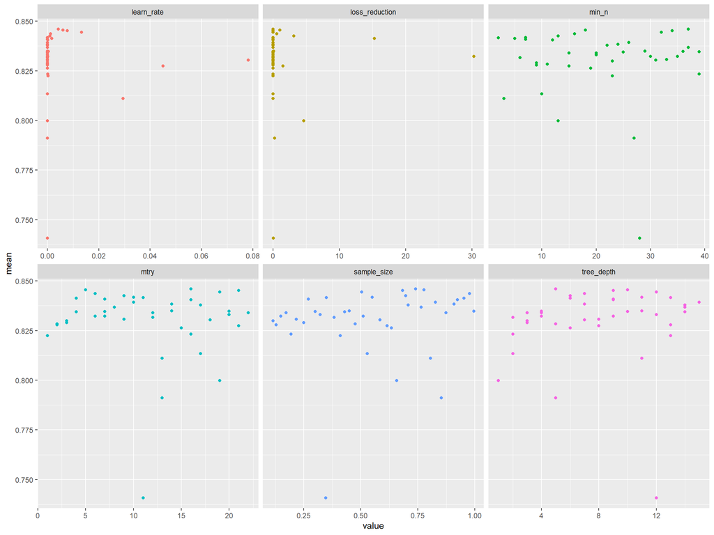

```r
xgb_tune %>%
  collect_metrics() %>%
  filter(.metric == "roc_auc") %>%
  select(mean, mtry:sample_size) %>%
  pivot_longer( mtry:sample_size,
    values_to = "value",
    names_to = "parameter"
  ) %>%
  ggplot(aes(value, mean, color = parameter)) +
  geom_point(show.legend = FALSE) +
  facet_wrap(~parameter, scales = "free_x")
```

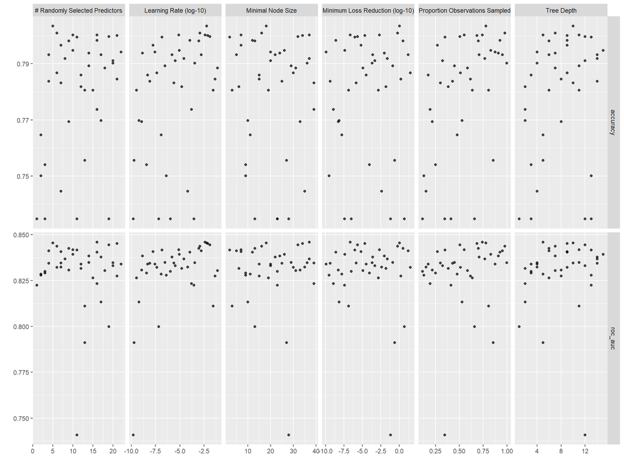

```r
autoplot(xgb_tune)
```

This plot shows the results of each. There’s not really an indication of a range for each argument - maybe a higher tree_depth. For example, it’s hard to tell if a higher or lower mtry will give us a higher mean, generally.

We can look at the parameters for the best models based on accuracy and roc_auc

```r
show_best(xgb_tune, "roc_auc") |> kable()
```

| mtry | min_n | tree_depth | learn_rate | loss_reduction | sample_size | .metric | .estimator | mean | n | std_err | .config |
| --- | --- | --- | --- | --- | --- | --- | --- | --- | --- | --- | --- |
| 16 | 37 | 5 | 0.0042413 | 0.0000002 | 0.7407727 | roc_auc | binary | 0.8459393 | 10 | 0.0055821 | Preprocessor1_Model21 |
| 5 | 18 | 10 | 0.0060422 | 1.0659622 | 0.7772719 | roc_auc | binary | 0.8454827 | 10 | 0.0052444 | Preprocessor1_Model16 |
| 21 | 34 | 9 | 0.0077551 | 0.0000214 | 0.6841453 | roc_auc | binary | 0.8452450 | 10 | 0.0055234 | Preprocessor1_Model32 |
| 19 | 32 | 12 | 0.0132575 | 0.0000021 | 0.5042190 | roc_auc | binary | 0.8444505 | 10 | 0.0053582 | Preprocessor1_Model26 |
| 6 | 16 | 7 | 0.0012132 | 0.5612216 | 0.9770812 | roc_auc | binary | 0.8436718 | 10 | 0.0052316 | Preprocessor1_Model35 |

```r
best_xgb <- select_best(xgb_tune, "roc_auc")
```

…And then we can plug into the testing data

```r
xgb_final <-
  xgb_wf |>
  finalize_workflow(best_xgb) |>
  last_fit(churn_split)

saveRDS(xgb_final, file = "Saved_Model_Results/xgb_final.rds")
```

```r
collect_metrics(xgb_final)
```

```
## # A tibble: 2 × 4
##   .metric  .estimator .estimate .config
##   <chr>    <chr>          <dbl> <chr>
## 1 accuracy binary         0.811 Preprocessor1_Model1
## 2 roc_auc  binary         0.856 Preprocessor1_Model1
```

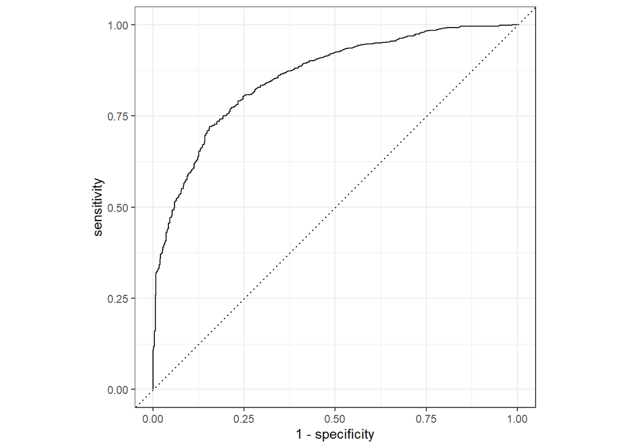

```r
# final_xgb |>
#   collect_predictions()

xgb_final %>%
  collect_predictions() %>%
  roc_curve(Churn, .pred_No) %>%
  autoplot()
```

The best roc_auc was 85.65, which is slightly worse than penalized logistic regression

```r
conf_mat_resampled(xgb_final)
```

```
## # A tibble: 4 × 3
##   Prediction Truth  Freq
##   <fct>      <fct> <dbl>
## 1 No         No     1175
## 2 No         Yes     214
## 3 Yes        No      119
## 4 Yes        Yes     254
```

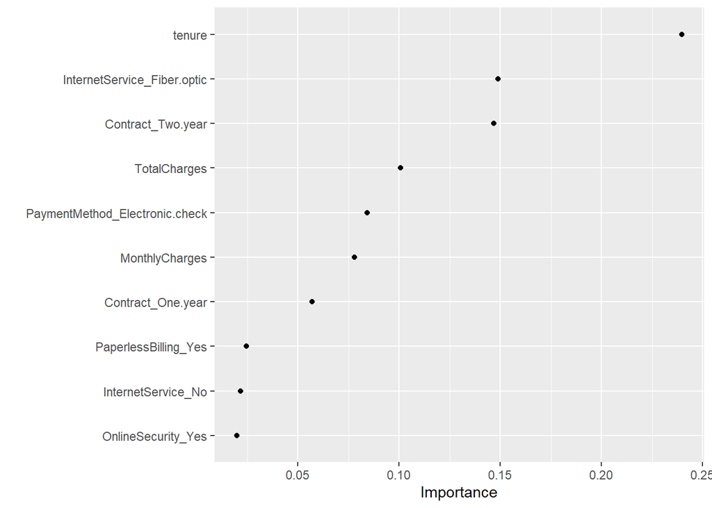

```r
xgb_vip <-
  xgb_spec %>%
  finalize_model(select_best(xgb_tune, 'roc_auc'))

workflow() |>
  add_recipe(model_recipe_no_norm) |>
  add_model(xgb_vip) |>
  fit(churn_train) %>%
  pull_workflow_fit() |>
  vip(geom = "point")
```

Tenure, Fiber_Optic, and 2-year contract are the most important

```
extract_workflow(xgb_final) |>
  extract_fit_parsnip() |>
  vip(num_features = 10)
```

## 5.4 SVM

Model information

- The fundamental idea behind SVMs is to find a hyperplane that best separates the data into different classes.
- It aims to find the hyperplane with the maximum margin - which is the distance between the hyperplane and the nearest data point from each class. A larger margin indicates better generalization to new data.
- The data points closest to the hyperplane and influence the position and orientation of the hyperplane are called support vectors. These are critical points that define the margin
- The radial basis function kernel defines a similarity measure between data points based on Euclidean distance
- RBF is used to capture complex or non-linear relationships

```r
svm_wf <-
  workflow() |>
  add_model(svm_spec) |>
  add_recipe(model_recipe_norm)
```

```r
svm_grid <- grid_regular(cost(),
                          rbf_sigma(),
                          levels = 7)
head(svm_grid,10) |> kable()
```

| cost | rbf_sigma |
| --- | --- |
| 0.0009766 | 0 |
| 0.0055243 | 0 |
| 0.0312500 | 0 |
| 0.1767767 | 0 |
| 1.0000000 | 0 |
| 5.6568542 | 0 |
| 32.0000000 | 0 |
| 0.0009766 | 0 |
| 0.0055243 | 0 |
| 0.0312500 | 0 |

```r
doParallel::registerDoParallel()
set.seed(345)

svm_tune <-
  svm_wf %>%
  tune_grid(
    resamples = churn_folds,
    control = control_grid(save_pred = TRUE),
    grid = svm_grid
    )
saveRDS(svm_tune, file = "Saved_Model_Results/svm_initial_tune.rds")
```

```r
collect_metrics(svm_tune) |> filter(.metric == "roc_auc") |> arrange(-mean) |> head(10) |> kable()
```

| cost | rbf_sigma | .metric | .estimator | mean | n | std_err | .config |
| --- | --- | --- | --- | --- | --- | --- | --- |
| 0.0055243 | 0.0004642 | roc_auc | binary | 0.8306937 | 10 | 0.0058946 | Preprocessor1_Model30 |
| 1.0000000 | 0.0000100 | roc_auc | binary | 0.8306001 | 10 | 0.0059001 | Preprocessor1_Model26 |
| 0.1767767 | 0.0000100 | roc_auc | binary | 0.8305956 | 10 | 0.0059907 | Preprocessor1_Model25 |
| 5.6568542 | 0.0000100 | roc_auc | binary | 0.8305394 | 10 | 0.0059177 | Preprocessor1_Model27 |
| 32.0000000 | 0.0000002 | roc_auc | binary | 0.8305298 | 10 | 0.0059932 | Preprocessor1_Model21 |
| 32.0000000 | 0.0000100 | roc_auc | binary | 0.8305229 | 10 | 0.0059021 | Preprocessor1_Model28 |
| 0.1767767 | 0.0004642 | roc_auc | binary | 0.8303904 | 10 | 0.0059034 | Preprocessor1_Model32 |
| 1.0000000 | 0.0004642 | roc_auc | binary | 0.8303445 | 10 | 0.0059228 | Preprocessor1_Model33 |
| 0.0312500 | 0.0004642 | roc_auc | binary | 0.8301473 | 10 | 0.0059805 | Preprocessor1_Model31 |
| 5.6568542 | 0.0004642 | roc_auc | binary | 0.8301276 | 10 | 0.0061092 | Preprocessor1_Model34 |

```r
show_best(svm_tune, "roc_auc") |> kable()
```

| cost | rbf_sigma | .metric | .estimator | mean | n | std_err | .config |
| --- | --- | --- | --- | --- | --- | --- | --- |
| 0.0055243 | 0.0004642 | roc_auc | binary | 0.8306937 | 10 | 0.0058946 | Preprocessor1_Model30 |
| 1.0000000 | 0.0000100 | roc_auc | binary | 0.8306001 | 10 | 0.0059001 | Preprocessor1_Model26 |
| 0.1767767 | 0.0000100 | roc_auc | binary | 0.8305956 | 10 | 0.0059907 | Preprocessor1_Model25 |
| 5.6568542 | 0.0000100 | roc_auc | binary | 0.8305394 | 10 | 0.0059177 | Preprocessor1_Model27 |
| 32.0000000 | 0.0000002 | roc_auc | binary | 0.8305298 | 10 | 0.0059932 | Preprocessor1_Model21 |

```r
best_svm <- select_best(svm_tune, "roc_auc")
```

```r
svm_final <-
  svm_wf |>
  finalize_workflow(best_svm) |>
  last_fit(churn_split)

saveRDS(svm_final, file = "Saved_Model_Results/svm_final.rds")
```

```r
collect_metrics(svm_final)
```

```
## # A tibble: 2 × 4
##   .metric  .estimator .estimate .config
##   <chr>    <chr>          <dbl> <chr>
## 1 accuracy binary         0.734 Preprocessor1_Model1
## 2 roc_auc  binary         0.845 Preprocessor1_Model1
```

## 5.5 K-Nearest Neighbor

Here are the arguments that will be tuned:

- Neighbors: an integer for the number of neighbors to consider - default is 5
- weight_function: indicates the kernal function - “rectangular”, “triangular”, “epanechnikov”, “biweight”, “triweight”, “cos”, “inv”, “gaussian”, “rank”, or “optimal”
- dist_power: a single number used in calculating the Minkowski distance. This parameter influences the sensitivity of the distance metric to different features - 1 is the manhattan distance, 2 is Euclidean

recipe knn_spec <- nearest_neighbor(neighbors = tune(), dist_power = tune(), weight_func = tune()) %>% set_engine(“kknn”) %>% set_mode(“classification”)

```r
knn_wf <-
  workflow() |>
  add_model(knn_spec) |>
  add_recipe(model_recipe_norm)
```

```r
knn_grid <- grid_regular(neighbors(),
                         dist_power(),
                         weight_func(),
                         levels = 4)
head(knn_grid,10)
```

```
## # A tibble: 10 × 3
##    neighbors dist_power weight_func
##        <int>      <dbl> <chr>
##  1         1       1    rectangular
##  2         4       1    rectangular
##  3         7       1    rectangular
##  4        10       1    rectangular
##  5         1       1.33 rectangular
##  6         4       1.33 rectangular
##  7         7       1.33 rectangular
##  8        10       1.33 rectangular
##  9         1       1.67 rectangular
## 10         4       1.67 rectangular
```

```r
doParallel::registerDoParallel()
set.seed(4575)

knn_tune <-
  knn_wf %>%
  tune_grid(
    resamples = churn_folds,
    control = control_grid(save_pred = TRUE),
    grid = knn_grid
    )
saveRDS(knn_tune, file = "Saved_Model_Results/knn_initial_tune.rds")
```

Since the grid only had 4 levels, only 4 of the 10 distance weighting functions were included. Rectangular performs the best and more neighbors perform better across the board. Dist power doesn’t appear to matter much.

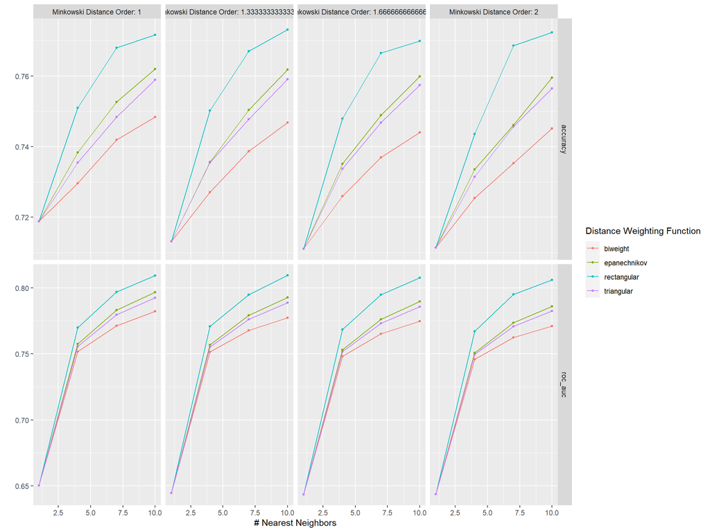

```r
autoplot(knn_tune)
```

Create a new grid and retune

```r
knn_grid <- grid_regular(neighbors(range = c(10,50)),
                         dist_power(range(1,2)),
                         weight_func(values = 'rectangular'),
                         levels = 7)

knn_retune <-
  knn_wf %>%
  tune_grid(
    resamples = churn_folds,
    control = control_grid(save_pred = TRUE),
    grid = knn_grid
    )
saveRDS(knn_retune, file = "Saved_Model_Results/knn_retuned.rds")

#autoplot(knn_retune)
```

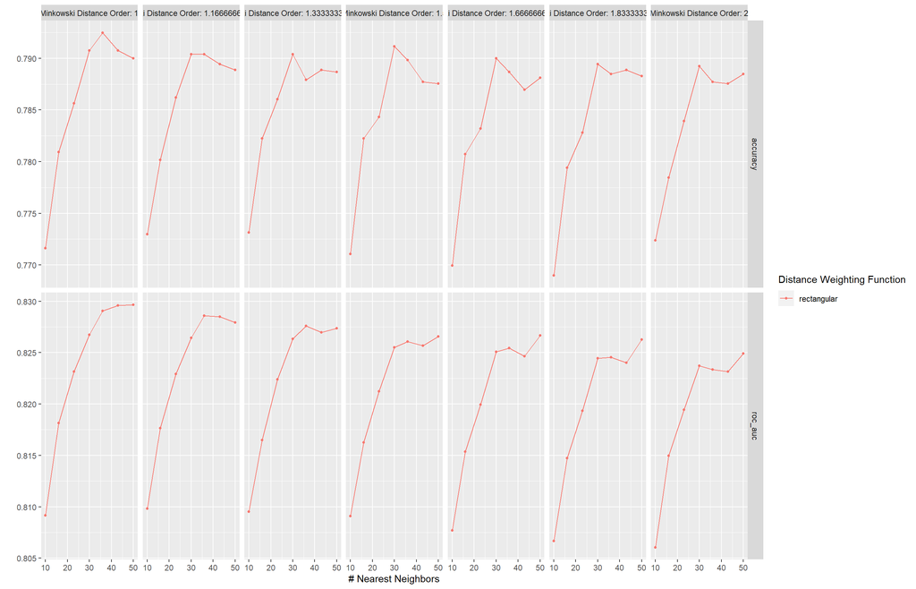

```r
autoplot(knn_retune)
```

```r
collect_metrics(knn_retune) |> filter(.metric == "roc_auc") |> arrange(-mean) |> head(10)
```

```
## # A tibble: 10 × 9
##    neighbors weight_func dist_power .metric .estimator  mean     n std_err
##        <int> <chr>            <dbl> <chr>   <chr>      <dbl> <int>   <dbl>
##  1        50 rectangular       1    roc_auc binary     0.830    10 0.00449
##  2        43 rectangular       1    roc_auc binary     0.830    10 0.00493
##  3        36 rectangular       1    roc_auc binary     0.829    10 0.00525
##  4        36 rectangular       1.17 roc_auc binary     0.829    10 0.00500
##  5        43 rectangular       1.17 roc_auc binary     0.829    10 0.00493
##  6        50 rectangular       1.17 roc_auc binary     0.828    10 0.00468
##  7        36 rectangular       1.33 roc_auc binary     0.828    10 0.00492
##  8        50 rectangular       1.33 roc_auc binary     0.827    10 0.00471
##  9        43 rectangular       1.33 roc_auc binary     0.827    10 0.00496
## 10        30 rectangular       1    roc_auc binary     0.827    10 0.00496
## # ℹ 1 more variable: .config <chr>
```

```r
show_best(knn_retune, "roc_auc")
```

```
## # A tibble: 5 × 9
##   neighbors weight_func dist_power .metric .estimator  mean     n std_err
##       <int> <chr>            <dbl> <chr>   <chr>      <dbl> <int>   <dbl>
## 1        50 rectangular       1    roc_auc binary     0.830    10 0.00449
## 2        43 rectangular       1    roc_auc binary     0.830    10 0.00493
## 3        36 rectangular       1    roc_auc binary     0.829    10 0.00525
## 4        36 rectangular       1.17 roc_auc binary     0.829    10 0.00500
## 5        43 rectangular       1.17 roc_auc binary     0.829    10 0.00493
## # ℹ 1 more variable: .config <chr>
```

```r
best_knn <- select_best(knn_retune, "roc_auc")
```

```r
knn_final <-
  knn_wf |>
  finalize_workflow(best_knn) |>
  last_fit(churn_split)

saveRDS(knn_final, file = "Saved_Model_Results/knn_final.rds")
```

```r
collect_metrics(knn_final)
```

```
## # A tibble: 2 × 4
##   .metric  .estimator .estimate .config
##   <chr>    <chr>          <dbl> <chr>
## 1 accuracy binary         0.794 Preprocessor1_Model1
## 2 roc_auc  binary         0.841 Preprocessor1_Model1
```

# 6 Bringing it all together

```r
model_results <- rbind(
  collect_metrics(glmnet_final) |> select(.metric, .estimate) |> mutate(model = 'glmnet'),
  collect_metrics(rf_final) |> select(.metric, .estimate) |> mutate(model = 'RF'),
  collect_metrics(xgb_final) |> select(.metric, .estimate) |> mutate(model = 'xgb'),
  collect_metrics(svm_final) |> select(.metric, .estimate) |> mutate(model = 'svm'),
  collect_metrics(knn_final) |> select(.metric, .estimate) |> mutate(model = 'knn')
)

model_results |> arrange(desc(.metric),desc(.estimate)) |> kable(align = 'c', caption = "All Model Results")
```

All Model Results

| .metric | .estimate | model |
| --- | --- | --- |
| roc_auc | 0.8580794 | glmnet |
| roc_auc | 0.8564933 | xgb |
| roc_auc | 0.8537547 | RF |
| roc_auc | 0.8451201 | svm |
| roc_auc | 0.8405263 | knn |
| accuracy | 0.8110102 | xgb |
| accuracy | 0.8070375 | glmnet |
| accuracy | 0.8036322 | RF |
| accuracy | 0.7939841 | knn |
| accuracy | 0.7343927 | svm |

The lasso model produced the best area under the ROC curve and XGBoost produced the best accuracy. The area under the ROC curve is just slightly better than XGB